# Multilevel Models in Julia

##### February 23, 2021

Today We will have a fun session doing regression and multilevel models(MLMs) using Julia. First, we will have a small exercise fitting a linear regression model to a sample dataset, and then we will fit the MLM to the same dataset and compare the difference in results. Can't wait? Let's get started! Yay!

# Set up

## Install Packages

In Julia, we can add package by typing "]" in the Terminal to enter the `Pkg` mode and exit using `Ctrl + C`. Or, we can use [`Pkg`] package and add multiple packages at once.

```julia
#= uncomment below to install packages
using Pkg
Pkg.add(["Pipe", "DataFrames", "StatFiles", "GLM","MixedModels","Plots", "StatsPlots")
=#
```

## Using Packages

Just like we use `library` to load packages in R, we use `using` in Julia. It's better to have a separate session in the beginning of the file to load all packages you will need in the analysis. Otherwise it will take a long time to precompile each time.

`Pipe` for pipe operator. `DataFrames` for working with dataframes. `StatFiles` for reading datasets from Stata, SPSS and SAS. If you have a txt file, can try CSV.read function from package `CSV`. `GLM` for linear regression. `MixedModels` for working with multilevel models. Similar to lme4. `Plots` for making graphs. `StatsPlots` for making graphs.

```julia
using Pipe, DataFrames, StatFiles, GLM, MixedModels, Plots, StatsPlots, Statistics
```

## Dataset

Today we are going to use the dataset from the World Value Survey-1990-93 data (World Values Study Group, 1994). There are five variables in the data set:

`CountryID`: CountryID  
`country`: Country's name  
`gm_GNP`: Grand-mean centered Gross National Product  
`income`: Income level(0-least income to 9-most income)  
`happy`:Feel happy(1-not happy to 4-very happy)

This data set and set of practice problem come from Mark's Multilvel Modeling class, so thanks Mark!

```julia
data_happy = DataFrame(load("happy_combined.sav"))
#= Or we can use pipe operator
data_happy = load("happy_combined.sav") |> DataFrame
=#
data_happy = dropmissing(data_happy)
```

|  | CountryID Float64 | country String | income Float64 | happy Float64 | gm_GNP Float64 |
| --- | --- | --- | --- | --- | --- |
| 1 | 1.0 | France | 1.0 | 4.0 | 0.8794 |
| 2 | 1.0 | France | 2.0 | 2.0 | 0.8794 |
| 3 | 1.0 | France | 2.0 | 4.0 | 0.8794 |
| 4 | 1.0 | France | 5.0 | 3.0 | 0.8794 |
| 5 | 1.0 | France | 4.0 | 3.0 | 0.8794 |
| 6 | 1.0 | France | 2.0 | 3.0 | 0.8794 |
| 7 | 1.0 | France | 3.0 | 2.0 | 0.8794 |
| 8 | 1.0 | France | 6.0 | 4.0 | 0.8794 |
| 9 | 1.0 | France | 1.0 | 3.0 | 0.8794 |
| 10 | 1.0 | France | 5.0 | 3.0 | 0.8794 |
| 11 | 1.0 | France | 1.0 | 1.0 | 0.8794 |
| 12 | 1.0 | France | 7.0 | 3.0 | 0.8794 |
| 13 | 1.0 | France | 8.0 | 3.0 | 0.8794 |
| 14 | 1.0 | France | 6.0 | 3.0 | 0.8794 |
| 15 | 1.0 | France | 9.0 | 4.0 | 0.8794 |
| 16 | 1.0 | France | 0.0 | 3.0 | 0.8794 |
| 17 | 1.0 | France | 9.0 | 3.0 | 0.8794 |
| 18 | 1.0 | France | 0.0 | 3.0 | 0.8794 |
| 19 | 1.0 | France | 4.0 | 3.0 | 0.8794 |
| 20 | 1.0 | France | 1.0 | 3.0 | 0.8794 |
| 21 | 1.0 | France | 7.0 | 3.0 | 0.8794 |
| 22 | 1.0 | France | 9.0 | 4.0 | 0.8794 |
| 23 | 1.0 | France | 5.0 | 4.0 | 0.8794 |
| 24 | 1.0 | France | 3.0 | 4.0 | 0.8794 |
| ⋮ | ⋮ | ⋮ | ⋮ | ⋮ | ⋮ |

# Research Questions

Are people with higher individual level income happier? Is the relation similar across countries? How is the result of linear regression different from the result of multilevel models?

## Descriptive Analysis

```julia
## Summary of all variables in the dataset
describe(data_happy)
## list first five rows of data
first(data_happy,5)
## list names of all variables
names(data_happy)
## get size of the data set
size(data_happy)
size(data_happy,1)
size(data_happy,2)
## check a specific column
data_happy[:,"country"]
# data_happy[!,:2]; data_happy[:,2] also work for extracting the second columns
# data_happy[2,:] can extract the second row, data_happy[2:5,:] extract the second to fifth row.
```

```
5926-element Array{String,1}:
 "France"
 "France"
 "France"
 "France"
 "France"
 "France"
 "France"
 "France"
 "France"
 "France"
 ⋮
 "Russia"
 "Russia"
 "Russia"
 "Russia"
 "Russia"
 "Russia"
 "Russia"
 "Russia"
 "Russia"
```

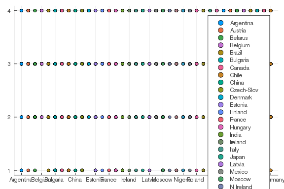

```julia
@df data_happy scatter(
    :country,
    :happy,
    group = :country)
```

## Linear Regression

???Exercise Time: We are familiar with our dataset, so let's do some exercise! Recall Winnie did a great presentation last time on linear regression, so please go ahead to fit a linear regression model and write out the equation.

Hint: Model*name = lm(@formula(DV ~ IV), data*set)

### Fitting the linear regression model

```julia
lm1 = lm(@formula(happy~ gm_GNP),data_happy)
# extract coefficients
coef(lm1)
# extract standard errors
stderror(lm1)
# extract variance covariance matrix
vcov(lm1)
# obtain R^2
r2(lm1)
# get the deviance
deviance(lm1)
```

```
3051.8666777811077
```

This model explains 4.72% of variance in `happy`. Note the standard error estimates for `gm_GNP` is 0.010, t =17.13, 95% CI [0.155 0.195], p < 0.0001.

### Equations

\[ \text{happy} = 2.992 + 0.175 \text{gm_GNP} \]

## Multilevel Modeling

### Random Intercept Model

We first fit a random intercept model and calculate the intraclass correlation. Recall

#### Equations

Level 1:

\[ \text{happy}_{ij} = \beta_{0j} + e_{ij} \]

Level 2:

\[ \beta_{0j} = \gamma_{00} + u_{0j} \]

\[ \text{ICC} = \frac{\tau_0^2}{\tau_0^2 + \sigma^2} \]

```julia
## Fitting MLMs
mm1 = fit(LinearMixedModel, @formula(happy ~ (1|country)), data_happy)
## Create a vector and store the model fit statistics
model_fit= Vector{Float64}()
push!(model_fit,aic(mm1))
```

```
1-element Array{Float64,1}:
 12639.70521706601
```

??? Exercise Time: What is the value of ICC?

ICC = 0.0649/(0.0649 + 0.4842) = 0.118, so there is evidence that people's happiness level varies across countries. Variability at the country level accounts for 11.8% of the total variability of happiness level.

Design effect = 1 +(average cluster size - 1) x ICC. We have 5926 observations and 38 groups, so design effect = 1 + (5926/38 -1) x 0.118 = 19.28.

### Add Level 2 Predictor

It is reasonable to think `gm_GNP` is a cluster level predictor, so let's add it to our model.

#### Equations

Level 1:

\[ \text{happy}_{ij} = \beta_{0j} + e_{ij} \]

Level 2:

\[ \beta_{0j} = \gamma_{00} + \gamma_{01} \text{gm_GNP}_{j} + u_{0j}\\ \]

```julia
## Fitting MLMs
mm2 = fit(LinearMixedModel, @formula(happy ~ gm_GNP + (1|country)), data_happy)
push!(model_fit, aic(mm2))
# extract log likelihood
loglikelihood(mm2)
# extract Akaike's Information Criterion
aic(mm2)
# extract Bayesian Information Criterion
bic(mm2)
# extract degrees of freedom
dof(mm2)
# extract coefficient
coef(mm2)
# extract fixed effects
fixef(mm2)
vcov(mm2)
stderror(mm2)
# extract coefficients table
coeftable(mm2)
# extract variance components
VarCorr(mm2)
# return sigma^2
varest(mm2)
# return sigma
sdest(mm2)
# extract random effects
ranef(mm2)
```

```
1-element Array{Array{Float64,2},1}:
 [0.10089772039022404 0.10460335801569388 … 0.1657853913370351 -0.180884607
49379742]
```

Note that the result is slightly different from the R output, it's because the default estimation method in [`MixedModels`] in Julia is maximum likelihood estimation, whereas the default estimation method for [`lme4`] in R is Restricted maximum likelihood method.

This time standard error estimates for `gm_GNP` is 0.0337, z = 5.33, p < 0.0001. The SE for OLS is smaller than the SE for MLM, indicating OLS underestimates the SE.

## Add Level 1 predictor

Because relationships at one level are not necessarily the same at the other level, we need to be careful adding the level 1 predictor. Two approaches to decompose the impact of level 1 predictor on outcome variables: cluter mean centering + cluster mean and the raw predictor + clutster mean. Here we will use the first approach.

#### Equations

Level 1:

\[ \text{happy}_{ij} = \beta_{0j} + \beta_{1j} \text{income_cmc}_{ij} + e_{ij} \]

Level 2:

\[ \beta_{0j} = \gamma_{00} + \gamma_{01} \text{income_mean}_{j} + u_{0j}\\ \beta_{1j} = \gamma_{10} + u_{1j} \]

```julia
## Cluster mean centering
data_happy2 = @pipe data_happy |>
            groupby(_,:country) |> # group by country
            transform(_, :income => mean => :income_mean)|> # add a new variable income_mean
            transform(_, [:income, :income_mean]=> ByRow(-) => :income_cmc) # add a new variable the centered variable

## Fitting MLMs
mm3 = fit(LinearMixedModel, @formula(happy ~ income_cmc + income_mean + (income_cmc|country)), data_happy2)
push!(model_fit, aic(mm3))
```

```
3-element Array{Float64,1}:
 12639.70521706601
 12620.520747678478
 12441.89124874437
```

## Cross level Interaction

Is the relation between `happy` and `income` moderated by `gm_GNP`? We can answer this question by adding `gm_GNP` to the above model.

```julia
mm4 = fit(LinearMixedModel, @formula(happy ~ income_cmc * gm_GNP + income_mean + (income_cmc|country)), data_happy2)
push!(model_fit, aic(mm4))
```

```
4-element Array{Float64,1}:
 12639.70521706601
 12620.520747678478
 12441.89124874437
 12425.031231147392
```

After adding `gm_GNP`, the impact of `income_mean` on `happy` is not significant.

#### Equations

Level 1:

\[ \text{happy}_{ij} = \beta_{0j} + \beta_{1j} \text{income_cmc}_{ij} + e_{ij} \]

Level 2:

\[ \beta_{0j} = \gamma_{00} + \gamma_{01} \text{income_mean}_{j} + \gamma_{02} \text{gm_GNP}_{j} + u_{0j}\\ \beta_{1j} = \gamma_{10} + \gamma_{11} \text{gm_GNP}_{j} + u_{1j} \]

??? Exercise time: 1. Which model fits data better?

```julia
# print out the AIC
print(model_fit)
# Likelihood Ratio Test
MixedModels.likelihoodratiotest(mm1,mm2,mm3,mm4)
```

```
[12639.70521706601, 12620.520747678478, 12441.89124874437, 12425.0312311473
92]Model Formulae
1: happy ~ 1 + (1 | country)
2: happy ~ 1 + gm_GNP + (1 | country)
3: happy ~ 1 + income_cmc + income_mean + (1 + income_cmc | country)
4: happy ~ 1 + income_cmc + gm_GNP + income_mean + income_cmc & gm_GNP + (1
 + income_cmc | country)
────────────────────────────────────────────────────
     model-dof    deviance        χ²  χ²-dof  P(>χ²)
────────────────────────────────────────────────────
[1]          3  12633.7052
[2]          4  12612.5207   21.1845       1   <1e-5
[3]          7  12427.8912  184.6295       3  <1e-39
[4]          9  12407.0312   20.8600       2   <1e-4
────────────────────────────────────────────────────
```

# Conclusion

The results of [`MixedModels`] in Julia and [`lme4`] are slightly different due to the estimation methods that are used. The cross-level interaction model fits best to our data, suggesting the country level GNP `gm_GNP` moderated the relation between individual's happiness level `happy` and income `income`.

# Resources

Mark's MLM class and HW

DataFrames package https://dataframes.juliadata.org/v0.14.0/index.html

MixedModels Package (similar to lme4 in R) documentation https://juliastats.org/MixedModels.jl/v1.0/index.html

Maybe useful for plotting week:

Gadfly Package (similar to ggplot in R) documentation https://juliastats.org/MixedModels.jl/v1.0/index.html

Published from Multilevel Models with Julia.jmd using Weave.jl v0.10.6 on 2021-02-23.